# A11_Python

## Getting Started with Python

```
Name: Ye Khaung Oo
Class: ENV 872 - Environmental Data Analytics
Date: Spring 2024
```

### Instructions

- Edit the markdown cell above to change `Your_name` to your name
- Complete the code cells below as instructed
- When complete, select "Save And Export Notebook As.." from the "File" menu and the save as an HTML file.
- Submit the HTML file to Sakai.

### 1. Working with variables and values

1. In the code cell below, create and assign values to the following 4 variables:

| Variable | Value |
| --- | --- |
| TreeID | 101 |
| Species | Oak |
| Height | 15.5 |
| Planted | False |

```python
#Create the four variables
TreeID = 101
Species = 'Oak'
Height = 15.5
Planted = False
```

2. In the 4 code cells below, display the *type* of each variable (one per code cell)

```python
#Show the type of the TreeID variable
type(TreeID)
```

```
int
```

```python
#Show the type of the Species variable
type(Species)
```

```
str
```

```python
#Show the type of the Height variable
type(Height)
```

```
float
```

```python
#Show the type of the Planted variable
type(Planted)
```

```
bool
```

3. Below are two code cells. The first [provided] creates a list of metrics for "Tree A". In the second code cell, combine the four variables created in Step 2 into a single list object named `tree_B`

```python
#Create a list describing Tree "A"
tree_A = [104,"Elm",12.1,True]
```

```python
#Create a list describing Tree "B" -- using the variables created above
tree_B = [101,"Oak",15.5,False]
```

4. Extract the height of tree B from tree A by first extracting the 3rd item from each list into their own variables and then using a comparative operator to evaluate whether Tree "A" is taller than Tree "B".

```python
#Extract the height from the list for Tree "A"
height_A = tree_A[2]
```

```python
#Extract the height from the list for Tree "B"
height_B = tree_B[2]
```

```python
#Evaluate whether Tree "A" is taller than Tree "B"
height_A > height_B
```

```
False
```

### 2. Working with data using NumPy and Pandas

#### 2a. Importing the packages

```python
#Import the numpy package, calling it "np"
import numpy as np
```

```python
#Import the pandas package, calling it "pd"
import pandas as pd
```

#### 2b. Creating and using Numpy arrays

```python
#Create a vector of tree height values, in meters
height_meters = np.array([2.1, 3.2, 5.6, 2.2, 3.1])
```

```python
#Compute the mean height in meters
np.mean(height_meters)
```

```
3.2400000000000007
```

```python
#Convert the values to cm
height_cm = height_meters * 100
```

```python
#Compute the median height in cm
np.median(height_cm)
```

```
310.0
```

► There are 39.37 inches in a meter. What is the median height of trees, in inches?

```python
#Convert matrix values from cm to inches
height_in = height_meters * 39.37
```

```python
#Compute the median of the heights in inches
np.median(height_in)
```

```
122.047
```

#### 2c. Working with dataframes in Pandas

```python
#Read the USGS dataset into a dataframe object
NTL_LTER = pd.read_csv("./data/Processed_KEY/NTL-LTER_Lake_ChemistryPhysics_PeterPaul_Processed.csv")
```

```python
#View the first 5 records
NTL_LTER.head()
```

|  | lakeid | lakename | year4 | daynum | month | sampledate | depth | temperature_C | dissolvedOxygen | irradianceWater | irradianceDeck | comments |
| --- | --- | --- | --- | --- | --- | --- | --- | --- | --- | --- | --- | --- |
| 0 | L | Paul Lake | 1984 | 148 | 5 | 1984-05-27 | 0.00 | 14.5 | 9.5 | 1750.0 | 1620.0 | NaN |
| 1 | L | Paul Lake | 1984 | 148 | 5 | 1984-05-27 | 0.25 | NaN | NaN | 1550.0 | 1620.0 | NaN |
| 2 | L | Paul Lake | 1984 | 148 | 5 | 1984-05-27 | 0.50 | NaN | NaN | 1150.0 | 1620.0 | NaN |
| 3 | L | Paul Lake | 1984 | 148 | 5 | 1984-05-27 | 0.75 | NaN | NaN | 975.0 | 1620.0 | NaN |
| 4 | L | Paul Lake | 1984 | 148 | 5 | 1984-05-27 | 1.00 | 14.5 | 8.8 | 870.0 | 1620.0 | NaN |

Examine characteristics of our dataframe...

```python
#Display the data type of our NLT_LTER object
type(NTL_LTER)
```

```
pandas.core.frame.DataFrame
```

```python
#Reveal the column names
NTL_LTER.columns
```

```
Index(['lakeid', 'lakename', 'year4', 'daynum', 'month', 'sampledate', 'depth',
       'temperature_C', 'dissolvedOxygen', 'irradianceWater', 'irradianceDeck',
       'comments'],
      dtype='object')
```

```python
#Reveal the structure of our dataframe
NTL_LTER.info()
```

```
<class 'pandas.core.frame.DataFrame'>
RangeIndex: 21613 entries, 0 to 21612
Data columns (total 12 columns):
 #   Column           Non-Null Count  Dtype
---  ------           --------------  -----
 0   lakeid           21613 non-null  object
 1   lakename         21613 non-null  object
 2   year4            21613 non-null  int64
 3   daynum           21613 non-null  int64
 4   month            21613 non-null  int64
 5   sampledate       21613 non-null  object
 6   depth            21613 non-null  float64
 7   temperature_C    19442 non-null  float64
 8   dissolvedOxygen  19342 non-null  float64
 9   irradianceWater  15451 non-null  float64
 10  irradianceDeck   14626 non-null  float64
 11  comments         244 non-null    object
dtypes: float64(5), int64(3), object(4)
memory usage: 2.0+ MB
```

```python
#Reveal the dimensions of our dataframe
NTL_LTER.shape
```

```
(21613, 12)
```

```python
#Use the `value_counts()` function to reveal how many records correspond to unique values in the `lakename` column.
NTL_LTER['lakename'].value_counts()
```

```
lakename
Peter Lake    11288
Paul Lake     10325
Name: count, dtype: int64
```

Check our date column and set it to a datetime object

```python
#Reveal datatype of the sampledate column
NTL_LTER['sampledate'].dtype
```

```
dtype('O')
```

```python
#Change it to a proper datetime object
NTL_LTER['sampledate'] = pd.to_datetime(NTL_LTER['sampledate'])
```

```python
#Reveal datatype of the datetime column
NTL_LTER['sampledate'].dtype
```

```
dtype('<M8[ns]')
```

### 3. Plotting with Plotnine/ggplot

```python
#Install plotnine (install if needed)
try:
    from plotnine import *
except:
    !pip install plotnine
    from plotnine import *
```

```
Downloading plotnine-0.13.3-py3-none-any.whl (1.3 MB)
   ━━━━━━━━━━━━━━━━━━━━━━━━━━━━━━━━━━━━━━━━ 1.3/1.3 MB 47.0 MB/s eta 0:00:00
Downloading mizani-0.11.1-py3-none-any.whl (127 kB)
   ━━━━━━━━━━━━━━━━━━━━━━━━━━━━━━━━━━━━━━━━ 127.3/127.3 kB 11.0 MB/s eta 0:00:00
```

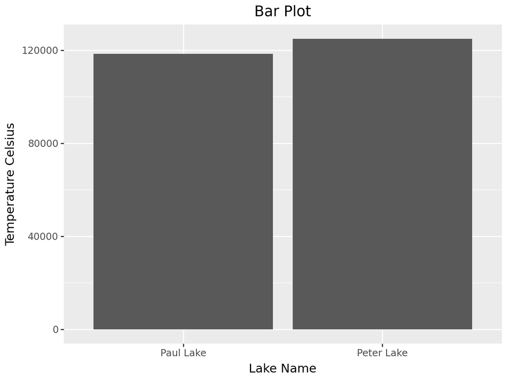

```python
#Create a bar plot of temperature by lakename
ggplot(NTL_LTER, aes(x='lakename', y='temperature_C')) + \
    geom_col() + \
    labs(title='Bar Plot', x='Lake Name', y='Temperature Celsius')
```

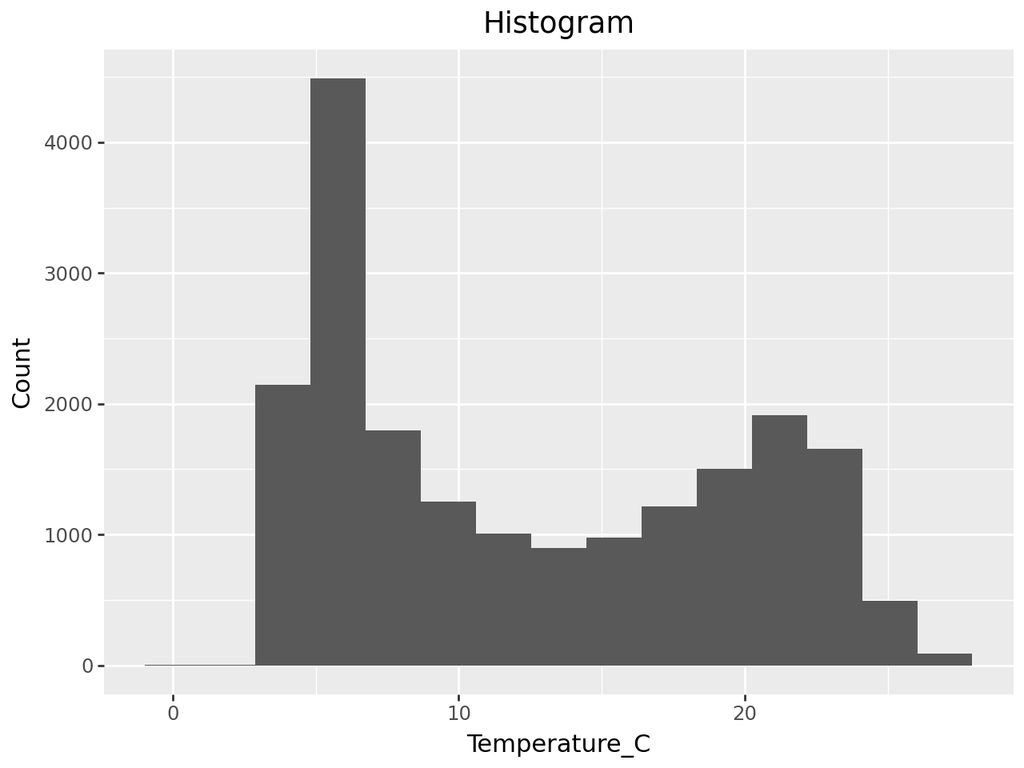

```python
#Create a histogram of temperature values using 15 bins
ggplot(NTL_LTER, aes(x='temperature_C')) + geom_histogram(bins=15) + labs(title='Histogram', x='Temperature_C', y='Count')
```

- Create a plot of irradiance of water vs depth, adding a regression line (geom_smooth) and scaling the y values from 0 to 2500.

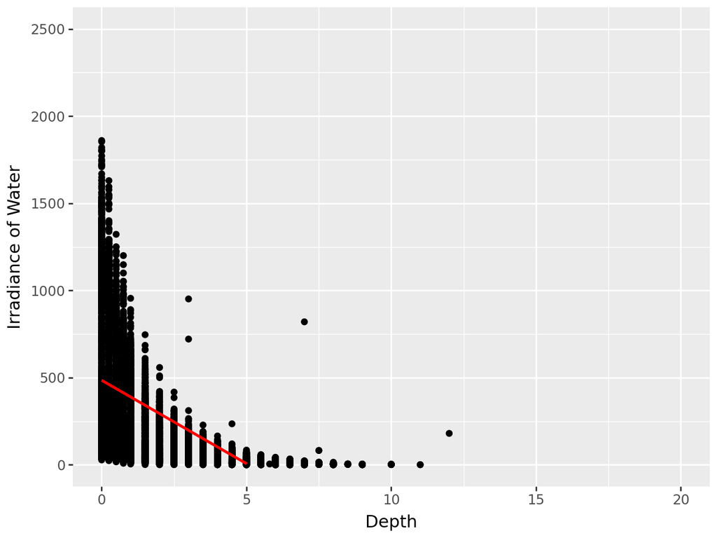

```python
#Create one more plot of your choosing
ggplot(NTL_LTER, aes(x='depth', y='irradianceWater')) + geom_point() + geom_smooth(method='lm', color='red') + ylim(0, 2500) + labs(x='Depth', y='Irradiance of Water')
```

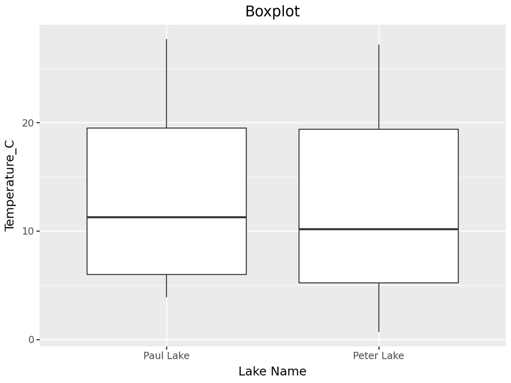

```python
ggplot(NTL_LTER, aes(x='lakename', y='temperature_C')) + \
    geom_boxplot() + \
    labs(title='Boxplot', x='Lake Name', y='Temperature_C')
```